# CEE 218X Assignment 7

Darren Wong

11/12/2021

# Difference-in-Differences Analysis of BART Station

The difference-in-differences method is a quasi-experimental approach that compares the changes in outcomes over time between a ‘treated group’ and a ‘control group’. It takes the before-after difference in the treatment group’s outcomes, controlling for factors that are constant over time in that group. Then to capture time-varying factors, difference-in-differences also takes the before-after difference in the control group, which was exposed to the same set of environmental conditions as the treatment group. It then subtracts the differences, leaving us with the impact estimation.

A difference-in-differences analysis was conducted to understand the impact of the new BART station, Antioch Station, which opened in mid-2018, on the surrounding neighborhoods. We might expect that with greater access to the BART network, more individuals living in neighborhoods around the BART station may use BART to commute to work. It can be hypothesised that the difference-in-differences analysis may reveal an increase in train ridership relative to similar populations in the Bay Area that did not experience a change in train access.

[interactive chart not shown]

The Antioch BART station (point marker) has a longitude and latitude of -121.7823 and 37.9957 respectively. The neighborhood identified for analysis is Brentwood, just east of the new BART station, where we expect the ‘treatment’ to be experienced. Brentwood was chosen as the neighborhoods immediately adjacent or on the north and west of Brentwood have existing BART stations, thereby diluting the effect of the new BART station on populations that previously did not have convenient access. Brentwood may be a promising site of study as residents may now find a car trip to the BART station and a transfer to BART a viable option.

[interactive chart not shown]

Comparing BART ridership trends from 2014 to 2017 and applying the Mahalonobis matching technique, the following 10 PUMAs in blue are similar to PUMA 01309.

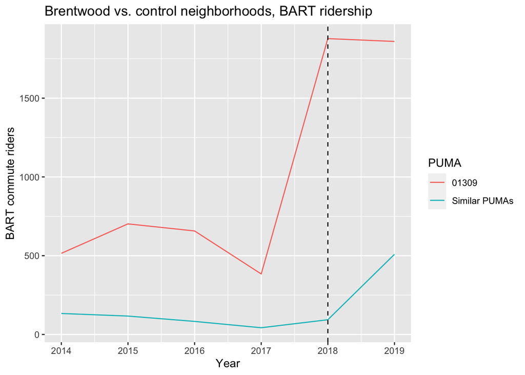

Based on the graph, the selected PUMA (01309) has an increase in BART ridership relative to the control PUMAs between 2017 to 2019 after the construction of the Antioch station in mid-2018. Running a difference-in-differences regression model to find the interaction between the treatment unit and the time of treatment, it appears that the Antioch BART station in 2018 has an estimated impact of about 1097 new BART commuters, which is statistically significant (p-value < 0.001).

```
##
## Call:
## lm(formula = bart ~ treated * time, data = transit_did)
##
## Residuals:
##     Min      1Q  Median      3Q     Max
## -301.10  -93.83  -53.30   64.67 1135.90
##
## Coefficients:
##              Estimate Std. Error t value Pr(>|t|)
## (Intercept)     93.82      36.51   2.570  0.01259 *
## treated        470.68     121.08   3.887  0.00025 ***
## time           207.28      63.23   3.278  0.00172 **
## treated:time  1097.22     209.72   5.232 2.11e-06 ***
## ---
## Signif. codes:  0 '***' 0.001 '**' 0.01 '*' 0.05 '.' 0.1 ' ' 1
##
## Residual standard error: 230.9 on 62 degrees of freedom
## Multiple R-squared:  0.6682, Adjusted R-squared:  0.6522
## F-statistic: 41.63 on 3 and 62 DF,  p-value: 7.327e-15
```

There are some choices and assumptions made in this analysis, such as: